# di-go teme za fanove

Danijel Kopčinović, IT Market

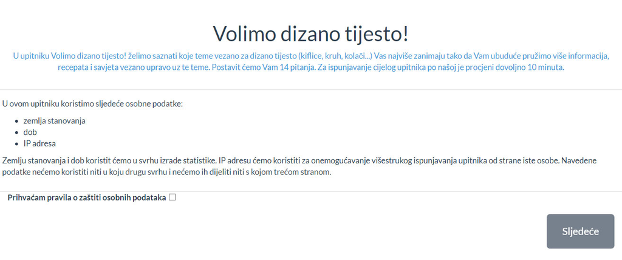

## Uvod

U ovom dokumentu ćemo prezentirati istraživanje tema koje najviše zanimaju di-go fanove. Koristili smo MaxDiff metodu u kojoj u svakom pitanju ispitanici biraju opciju koja ih najviše, odn. najmanje zanima. Na taj se način olakšava ispunjavanje upitnika i dobivaju relevantni rezultati.

Teme između kojih su ispitanici birali su:

```
##  [1] pizze (sve vrste)
##  [2] slane kiflice i peciva s punjenjem (šunka, sir…)
##  [3] slatke kiflice i peciva s punjenjem (pekmez, Nutella…)
##  [4] kolači s punjenjem (orahnjača, makovnjača, žarbo…)
##  [5] kolači s voćem (savijača s voćem, kuglof s voćem…)
##  [6] kruh (sve vrste) i pogače bez punjenja
##  [7] slane pogače s punjenjem (meso, povrće…)
##  [8] krafne, fritule, slatki uštipci (slatko prženo dizano tijesto)
##  [9] mala peciva bez punjenja (kiflice, kajzerice, žemlje…)
## [10] posebni blagdanski kolači (pinca, panettone, stollen…)
## [11] lijepo motanje i preklapanje tijesta (pogače, pletenice, ružice…)
## [12] lisnato dizano tijesto (salenjaci, kroasani, vijenci…)
## 12 Levels: kolači s punjenjem (orahnjača, makovnjača, žarbo…) ...
```

Sve kombinacije podijelili smo na 3 upitnika, od kojih svaki ima 8 pitanja, od kojih svako ima 3 opcije/alternative.

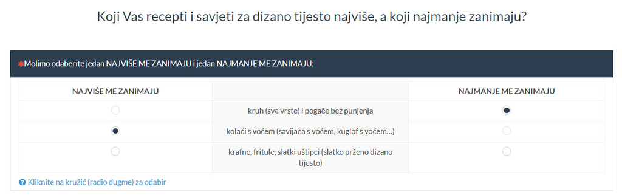

Ispitanicima smo postavili i nekoliko pitanja u kojima su iskazali općenito pozitivni ili negativni stav prema nekoliko odabranih tema. Ova pitanja nam omogućuju da bolje uskladimo odgovore svih ispitanika u odnosu na graničnu opciju (zanima me/ne zanima me) pa time i međusobno, čime dobivamo relevantne procjene vrijednosti.

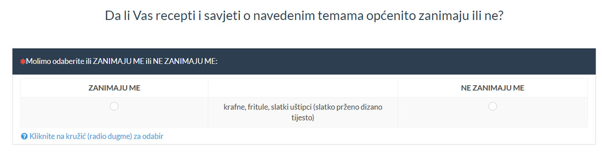

## Analiza

Podatke (odgovore ispitanika) smo analizirali Hierarchical Bayes multinomnim logit modelom. Hierarchical Bayes model nam daje individualne procjene vrijednosti (za svakog ispitanika).

Podatke smo prvo prilagodili za izračun a zatim izračunali koeficijente (“vrijednosti”) za svaku temu koju ispitujemo. Dobili smo sljedeći sažetak:

```
##                                                  1st Qu.      Mean  3rd Qu.
## pizze..sve.vrste....                        -0.753590574 0.5368577 1.827253
## slane.kiflice.i.peciva.s.punjenjem..šunk...  2.219724169 3.3519636 4.450090
## slatke.kiflice.i.peciva.s.punjenjem..pek...  1.343386166 2.4792697 3.602613
## kolači.s.punjenjem..orahnjača..makovnjač...  1.328730035 2.4464892 3.550362
## kolači.s.voćem..savijača.s.voćem..kuglof... -0.097087790 1.0231223 2.180383
## kruh..sve.vrste..i.pogače.bez.punjenja...    1.883506373 2.9016398 3.904107
## slane.pogače.s.punjenjem..meso..povrće..... -0.062261436 1.0671264 2.209644
## krafne..fritule..slatki.uštipci..slatko....  0.724305917 1.7937275 2.866471
## mala.peciva.bez.punjenja..kiflice..kajze...  0.937453020 2.1177492 3.289271
## posebni.blagdanski.kolači..pinca..panett... -0.009816361 1.2104487 2.432204
## lijepo.motanje.i.preklapanje.tijesta..po...  2.809583075 3.9708171 5.065251
## lisnato.dizano.tijesto..salenjaci..kroas...  1.796613118 2.8354859 3.859021
```

Sve koeficijente smo normalizirali i skalirali tako da granična opcija (zanima me/ne zanima me) bude na broju 100. Tako je lakše interpretirati vrijednosti tema i njihove međusobne omjere:

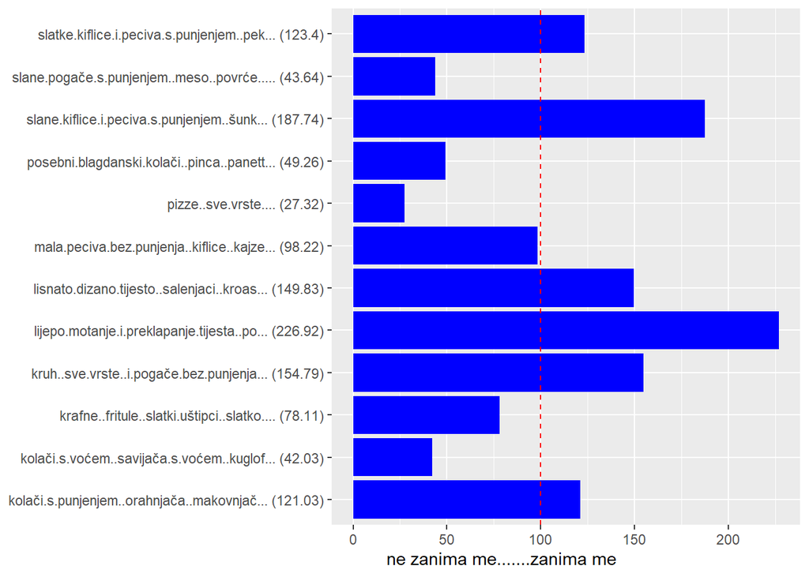

Sad možemo vidjeti da je npr. najzanimljivija tema **lijepo.motanje.i.preklapanje.tijesta..pogače..pletenice..ružice..** i da joj je “zanimljivost” **1.51 puta veća** od vrijednosti lisnato.dizano.tijesto..salenjaci..kroasani..vijenci…

Ovi rezultati pokazuju i glavne prednosti MaxDiff analize u odnosu na jednostavno “redanje” proizvoda od najboljeg prema najlošijem koje se ponekad (prečesto :)) koristi za poslovne analize. MaxDiff nam pokazuje:

- *odnose među proizvodima* - koliko je koji vredniji ili manje vrijedan za ispitanike,
- pozicije proizvoda *u odnosu na (ključnu!) točku koja označava pozitivan ili negativan stav* - kupio bih ili ne, zanima me ili ne…

Time dobivamo kompletnu sliku svih proizvoda iz perspektive ispitanika i možemo donositi kvalitetne poslovne odluke.

## Predviđanje udjela (share prediction)

Kad smo izračunali koeficijente za sve teme, možemo usporediti njihove različite kombinacije i predvidjeti koje bi teme publiku koliko zanimale kad bismo ih uspoređivali. Kao primjer uzet ćemo kombinaciju nekoliko slučajno odabranih tema i izračunati njihove predviđene udjele u “popularnosti”:

```
##         [,1]               [,2]               [,3]
## opcije  "slatke kiflic..." "pizze (sve vr..." "kolači s voće..."
## share % "19.04"            " 8.83"            "11.66"
##         [,4]               [,5]
## opcije  "kolači s punj..." "slane kiflice..."
## share % "22.30"            "38.18"
```

U prethodnoj tablici možemo vidjeti kako bi ispitanici birali između izabranih 5 tema. Svaka tema dobiva predviđeni udio (postotak) u ukupnoj “popularnosti”, prema procijenjenim vrijednostima pripadajućih koeficijenata.

Najčešće birana tema (između navedenih, ne općenito) je slane kiflice i peciva s punjenjem (šunka, sir…) s previđenim udjelom u “popularnosti” 38.18%.

## Provjera modela na postojećim podacima

Korištenjem predviđanja udjela/vjerojatnosti prodaje za razne kombinacije proizvoda, možemo testirati i kako bi naš model predvidio izbor za (neke) kombinacije koje su dane u istraživanju:

```
##                    choice
## respondent/question true best predicted best true worst predicted worst
##               87/4          3              3          2               2
##               81/5          1              1          2               2
##               45/6          2              2          1               1
##               92/5          1              1          2               2
##               52/4          2              2          3               3
##               56/6          2              2          3               3
##               2/4           1              1          2               2
##               81/6          3              3          1               1
##               101/6         1              1          3               3
##               96/6          3              3          1               1
##               13/6          3              3          1               1
##               3/4           3              3          1               1
##               108/6         3              3          1               1
##               10/6          3              3          1               1
##               11/5          2              2          3               3
##               32/5          3              3          1               1
##               42/4          3              3          1               1
##               11/4          3              3          1               1
##               25/5          3              3          2               2
##               107/5         2              2          3               3
```

```
## [1] "Ukupno točno predviđanja:91.39%"
```

Ukupna točnost predviđanja daje nam sigurnost da naš model dobro funkcionira.

## Zaključak

Zaključujemo da su teme koje najviše zanimaju di-go fanove:

|  | score |
| --- | --- |
| lijepo.motanje.i.preklapanje.tijesta..pogače..pletenice..ružice.. | 226.9238 |
| slane.kiflice.i.peciva.s.punjenjem..šunka..sir.. | 187.7413 |
| kruh..sve.vrste..i.pogače.bez.punjenja | 154.7935 |
| lisnato.dizano.tijesto..salenjaci..kroasani..vijenci.. | 149.8335 |
| slatke.kiflice.i.peciva.s.punjenjem..pekmez..Nutella.. | 123.4015 |
| kolači.s.punjenjem..orahnjača..makovnjača..žarbo.. | 121.0274 |

Prema navedenim rezultatima, predlažemo prilagodbu komunikacije i produkcije sadržaja na di-go Facebook stranici i drugim kanalima za optimiziranje dosega i aktivnosti.

**MaxDiff analiza je moćan alat za upoznavanje kupaca i njihovih vrijednosti i za kreiranje najboljih proizvoda za njih. Takav pristup uvijek vodi prema poboljšanju poslovanja, većim prihodima i većem zadovoljstvu kupaca.**

Za više informacija kontaktirajte **danijel.kopcinovic@itmarket.hr**.